# Stat-rethink Chapter 3

Mariana CHiozza

6/8/2020

# Sampling the Imaginary

## 3.1 Sampling from a grid-approxiate posterior

Grid approximation

1. Define the grid. How many data points to use. List of the parameter values.

```r
p_grid= seq(from=0, to=1, length.out = 1000)
```

2. Define the prior at each parameter value

```r
prob_p=rep(1,1000)
```

3. Compute likelihood at each value in grid

```r
prob_data=dbinom(6, size = 9, prob = p_grid) #six waters in 9 tosses
```

4. Compute the product (likelihood*prior)

```r
posterior=prob_data*prob_p
```

5. Standarize the posterior

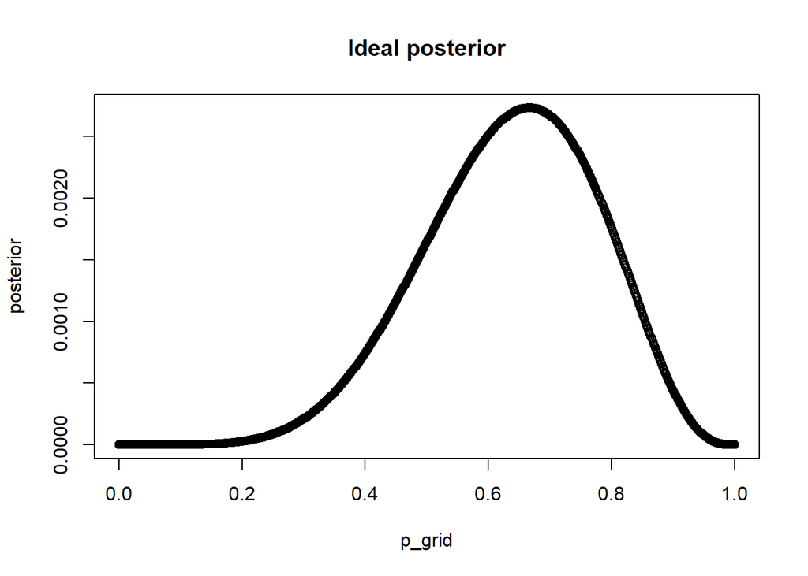

```r
posterior=posterior/sum(posterior)
plot(p_grid, posterior, main="Ideal posterior",)
```

Sampling the posterior: Samples will have the same proportion as the posterior density.

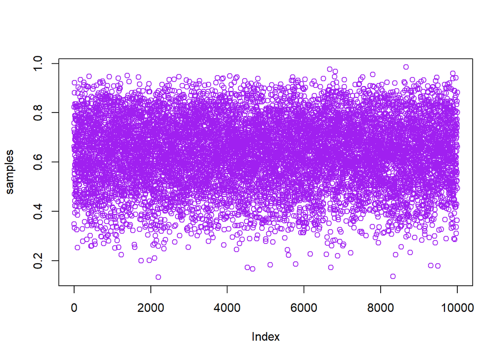

```r
samples=sample(p_grid, prob = posterior, size=10000, replace = TRUE)
plot(samples, col="purple")
library(rethinking)
```

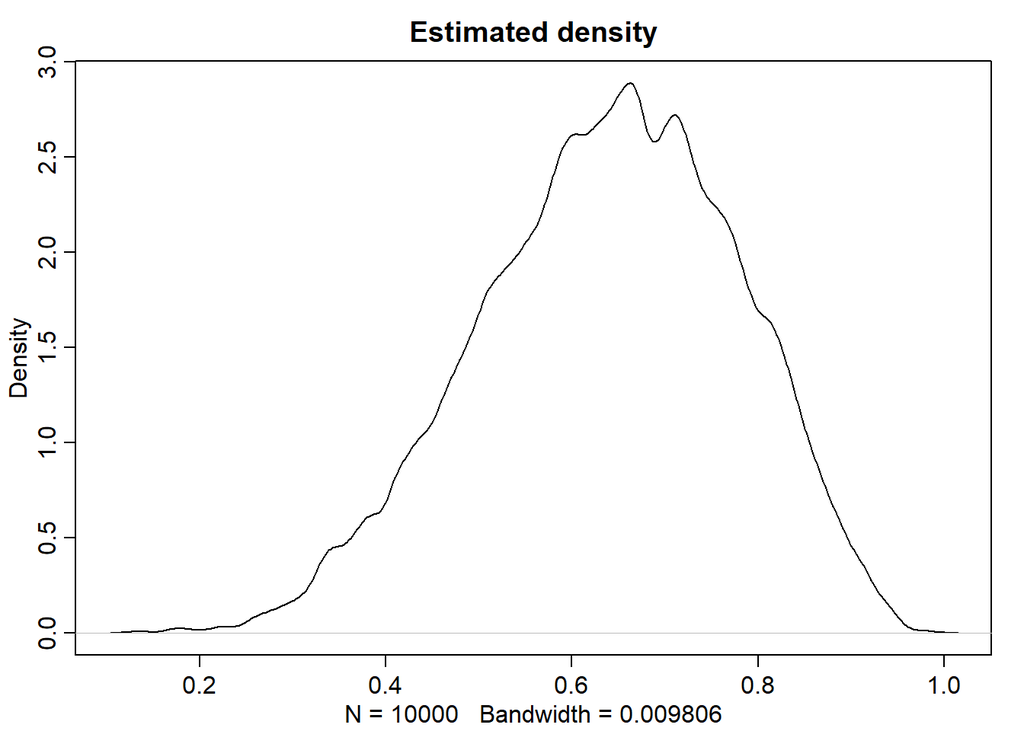

```r
dens(samples, main="Estimated density")
```

## 3.2 Sampling to summarize

Interpreting the posterior: What is the probability (posterior) for a parameter to lies below some number, or between two values.

Example: proportion of water is below 0.5.

Add all probability values from the grid posterior less than 0.5

```r
sum(posterior[p_grid<0.5])
```

```
## [1] 0.1718746
```

17% of the posterior probability is below 0.5.

Finding the frecuency of the values below 0.5

```r
sum(samples<0.5) /10000
```

```
## [1] 0.1666
```

Intervals:

- Confidence intervals
- Compatibility interval (avoiding confidence and credibility). Is is a range of values compatible with the model and data.
- Percentile intervals (PI)
- Highest posterior density interval

Use samples from the posterior instead of grid approximation. Example: 80th percentile:

```r
quantile(samples, 0.8)
```

```
##       80%
## 0.7607608
```

```r
quantile(samples, c(0.1, 0.9))
```

```
##       10%       90%
## 0.4523524 0.8138138
```

Percentile intervals (PI) and highest posterior density compatibility intervals (HPDI). For posterior distribution that are not symmetrical or highly skewed (three waters in three tosses) and a flat (uniform) prior.

```r
p_grid= seq(from=0, to=1, length.out = 1000)
prior=rep(1,1000)
likelihood=dbinom(3, size = 3, prob=p_grid)
posterior=likelihood*prior
posterior=posterior/sum(posterior)
samples=sample(p_grid, size = 10000, replace=TRUE, prob = posterior)

PI(samples,prob = 0.5)
```

```
##       25%       75%
## 0.7057057 0.9289289
```

```r
HPDI (samples, prob = 0.5)
```

```
##      |0.5      0.5|
## 0.8328328 0.9979980
```

Finally, summarizing the posterior probability: What unique value should we report from the entire posterior distribution?

Note: Is is harmful to report a single value when using Bayesian parameter estimate, where each parameter value has assigned a plausibility value following a function.

But….we can use the LOSS OF FUNCTION rule. It will tell you the cost associated with using any particular point estimate.

Three point estimates: maximum a posteriori, mean and median.

```r
p_grid[which.max(posterior)]
```

```
## [1] 1
```

```r
chainmode(samples, adj=0.01)
```

```
## [1] 0.9798585
```

```r
mean(samples)
```

```
## [1] 0.7980112
```

```r
median(samples)
```

```
## [1] 0.8348348
```

Compute the the loss, assumption p=0.5. Compute the weighted average loss, where each loss is weighted by its posterior probability.

```r
sum(posterior*abs(0.5-p_grid))
```

```
## [1] 0.3128752
```

```r
# Doing that for every possible desicion:

loss=sapply(p_grid, function(d)
  sum(posterior*abs(d - p_grid)))
```

Minimizying the loss (find the parameter value that minimize the loss)

```r
p_grid[which.min(loss)]
```

```
## [1] 0.8408408
```

The result is the posterior median.

```r
median(samples)
```

```
## [1] 0.8348348
```

## 3.3 Sampling to simulate prediction

Simulated data= Dummy Data Globe Tossing Model (binomial likelihood) with 2 tosses there are three posible outcomes (0 water, 1 water or 2 water). Calculate the probability of each outcome using p=0.7:

```r
dbinom(0:2, size = 2, prob = 0.7)
```

```
## [1] 0.09 0.42 0.49
```

There is 9% chance of w=0, 42% chance that w=1 and 49% chance for w=2.

Now, simulate using probabilities:

Sample 1 observation from the distribution

```r
rbinom(1, size = 2, prob = 0.7) #r stands for random
```

```
## [1] 0
```

```r
dummy_w=rbinom (100000, size = 2, prob = 0.7)
table(dummy_w)/100000
```

```
## dummy_w
##       0       1       2
## 0.08941 0.41987 0.49072
```

Executing the code multiple times will give slighlty different results.

## Practice

```r
p_grid= seq(from=0, to=1, length.out = 1000)
prior=rep(1,1000)
likelihood=dbinom(6, size = 9, prob=p_grid)
posterior=likelihood*prior
posterior=posterior/sum(posterior)

set.seed(100)
samples=sample(p_grid, prob = posterior, size = 10000, replace = TRUE)
```

### E1 to E7

```r
#Using grid approximation
sum(posterior[p_grid<0.2])
```

```
## [1] 0.0008560951
```

```r
sum(posterior[p_grid>0.8])
```

```
## [1] 0.1203449
```

```r
sum(posterior[p_grid>0.2 & p_grid<0.8])
```

```
## [1] 0.878799
```

```r
#Sampling from the posterior distribution
sum(samples<0.2)/10000
```

```
## [1] 4e-04
```

```r
sum(samples>0.8)/10000
```

```
## [1] 0.1116
```

```r
sum(samples>0.2 & samples<0.8)/10000
```

```
## [1] 0.888
```

```r
quantile(samples, 0.2)
```

```
##       20%
## 0.5185185
```

```r
quantile(samples, 0.8)
```

```
##       80%
## 0.7557558
```

```r
HPDI (samples, prob = 0.66)
```

```
##     |0.66     0.66|
## 0.5085085 0.7737738
```

```r
PI (samples, prob = 0.66)
```

```
##       17%       83%
## 0.5025025 0.7697698
```

## M1 to M6

```r
p_grid= seq(from=0, to=1, length.out = 1000)
prior=rep(1,1000)
likelihood=dbinom(8, size = 15, prob=p_grid)
posterior=likelihood*prior
posterior=posterior/sum(posterior)

set.seed(100)
samples=sample(p_grid, prob = posterior, size = 10000, replace = TRUE)

HPDI (samples, prob = 0.9)
```

```
##      |0.9      0.9|
## 0.3343343 0.7217217
```

```r
w=rbinom(10000, size = 15, prob = samples)
sum(w==8)/10000
```

```
## [1] 0.1499
```

```r
w=rbinom(10000, size = 9, prob = samples)
sum(w==6)/10000
```

```
## [1] 0.1842
```